# Homework Week5 day 1

```r
library(CodeClanData)
library(tidyverse)
```

```r
qb_revenue_breakdown <- janitor::clean_names(qb_revenue_breakdown)
qb_competitors <- janitor::clean_names(qb_competitors)
qb_device_data <- janitor::clean_names(qb_device_data)
qb_monthly_sales <- janitor::clean_names(qb_monthly_sales)

col_scheme <- c("#E89FE9", "#50434F", "#B6A7B5", "#F9A472", "#BD7040")

qikbit_theme <- function() {
  theme(panel.border = element_rect(colour = "#B6A7B5",
                                fill = NA,
                                linetype = 2),
    # color background 2)
    panel.background = element_rect(fill = "white"),
    # modify grid 3)
    panel.grid.major.x = element_line(colour = "#B6A7B5",
                                      linetype = 3,
                                      size = 0.5),
    panel.grid.minor.x = element_blank(),
    panel.grid.major.y =  element_line(colour = "#B6A7B5",
                                       linetype = 3,
                                       size = 0.5),
    panel.grid.minor.y = element_blank(),
    axis.text = element_text(size = 12,
                             colour = "#50434f",
                             family = "Times New Roman"),
    axis.title = element_text(size = 12,
                              colour = "#50434f",
                              family = "Times New Roman"),
    axis.ticks = element_line(colour = "#50434f"),
    legend.position = "bottom"
  )
}
```

# Part 1

## Question 1.

Take the data in the dataset qb_revenue_breakdown and make a stacked bar chart showing the sources of revenue across the two years in the dataset.

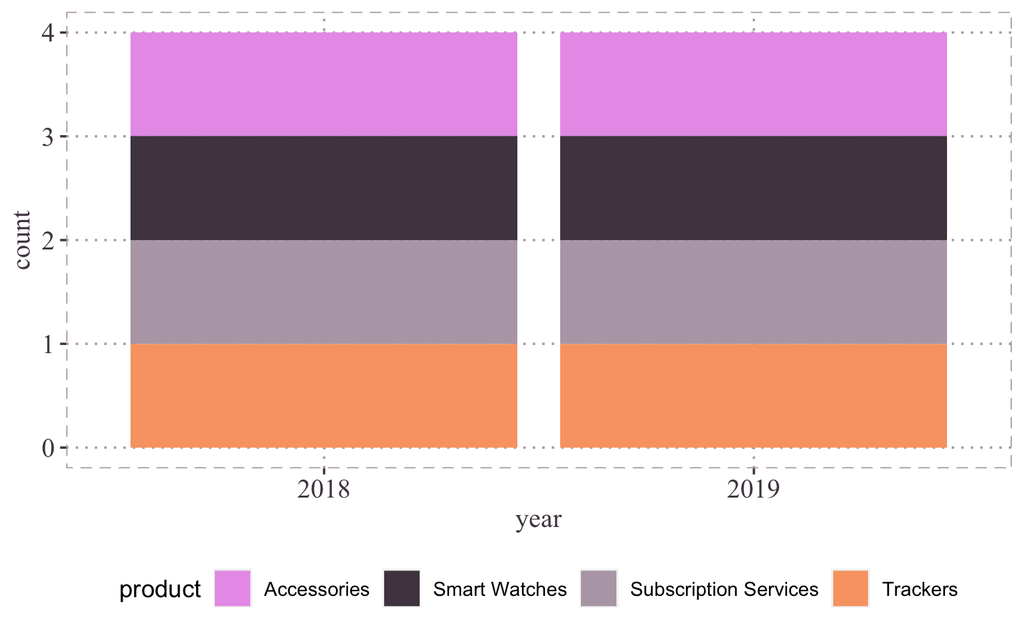

```r
qb_revenue_breakdown %>%
  ggplot(aes(x = year,
             fill = product)) +
  geom_bar() +
  qikbit_theme() +
  scale_fill_manual(values = col_scheme)
```

## Question 2.

Make a line chart showing monthly sales of the “flagship product” - the ‘KwikBit Unit 1’ - over the last year. This data is inside qb_monthly_sales, but you will need to use filter() or subset() (base R).

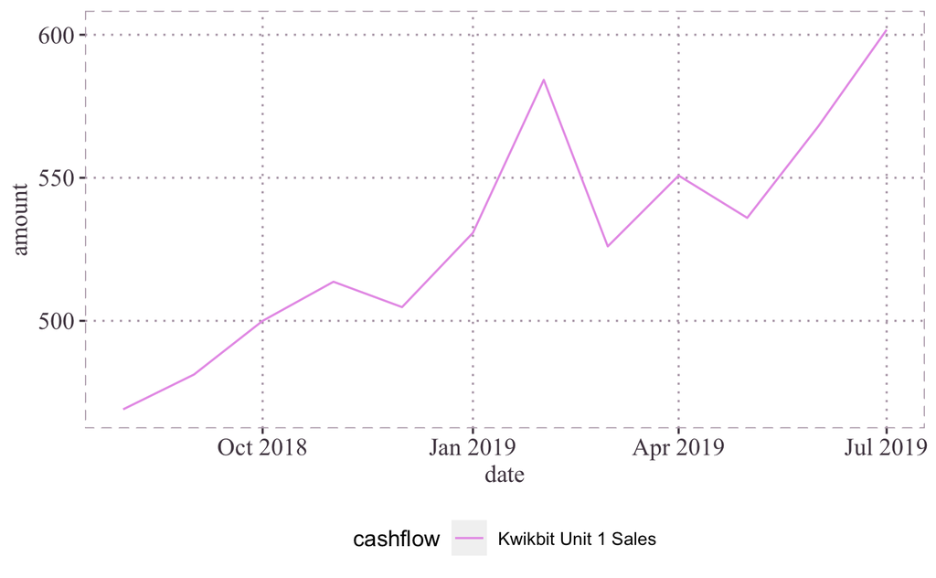

```r
qb_monthly_sales %>%
  filter(cashflow == "Kwikbit Unit 1 Sales") %>%
  ggplot(aes(x = date,
             y = amount,
             colour = cashflow)) +
  geom_line() +
  qikbit_theme() +
  scale_colour_manual(values = col_scheme)
```

```r
NA
```

## Question 3.

Make a line chart showing monthly revenue and costs over the last year. This data is also in qb_monthly_sales.

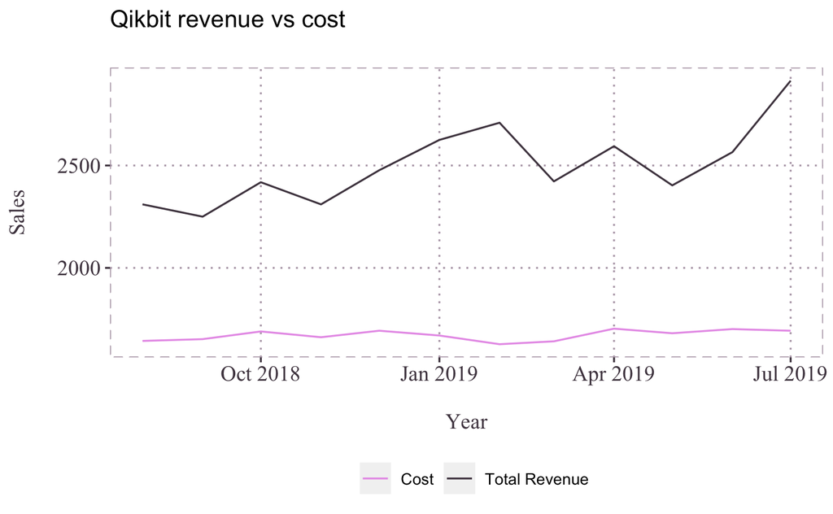

## Question 4.

Show annual sales of personal fitness trackers over the last 5 years broken down by company as a ribbon plot (use geom_area). This data is in qb_competitors.

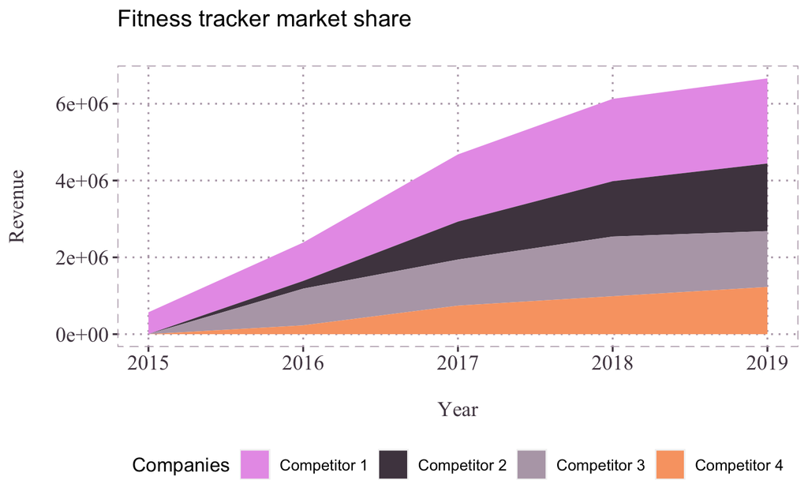

```r
qb_competitors %>%
  ggplot(aes(x = year,
             fill = company,
             y = revenue)) +
  geom_area() +
  labs(x = "\nYear",
       y = "Revenue\n",
       title = "Fitness tracker market share\n",
       fill = "Companies") +
  qikbit_theme() +
  scale_fill_manual(values = col_scheme)
```

## Question 5.

Now show the sales from the four competitors as a line graph. Include an extra layer that shows the data points used to make the lines.

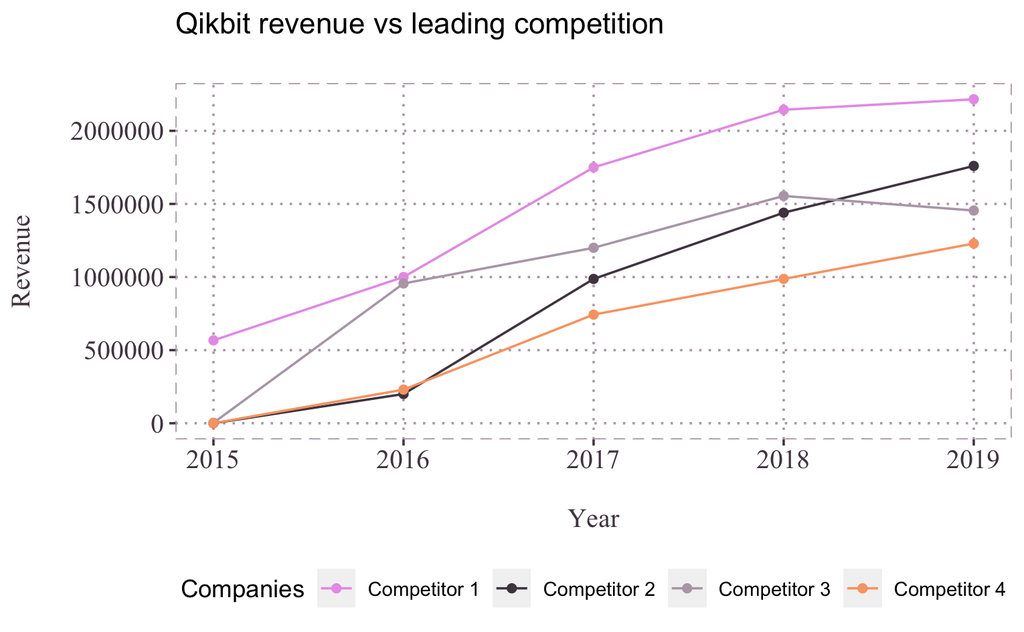

## Question 6.

Now the company wants to compare the number of steps that their device counts vs. their competitors. Make a line graph of the number of steps throughout time, and use faceting to compare between companies and people. The data for this is in qb_device_data.

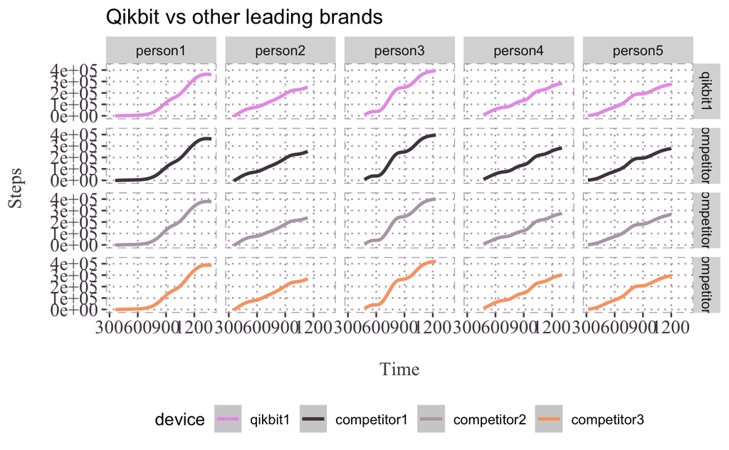

```r
cumul_device_data <- qb_device_data %>%
  group_by(device, id) %>%
  mutate(time = hours * 60 + mins,
         cumulative_steps = cumsum(counts)) %>%
  unnest(cols = c())


cumul_device_data %>%
  ggplot(aes(x = time,
             y = cumulative_steps
             )) +
  aes(colour = device) +
  geom_line(alpha = 0) +
  geom_smooth() +
  facet_grid(device ~ id) +
  scale_colour_manual(values = col_scheme) +
  labs(x = "\nTime",
       y = "Steps\n",
       title = "Qikbit vs other leading brands",
       fill = "Companies") +
  qikbit_theme()
```

# 2.2 Part 2